# PA1_template.Rmd

Loading and preprocessing the data

```r
q <-read.csv("activity.csv", header=TRUE)
s<-aggregate(q$steps,by=list(q$date),sum)
totalsteps<-s$x
```

What is mean total number of steps taken per day?

1. Here is a histogram of the total number of steps taken each day:

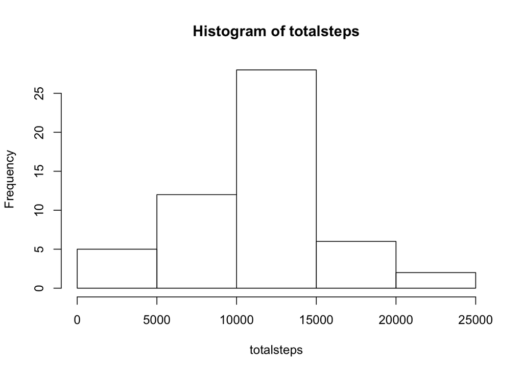

```r
hist(totalsteps)
```

2. First table is the mean of steps in day, and the second is the median of steps in each day:

```r
aggregate(q$steps,by=list(q$date),mean)
```

```
##       Group.1       x
## 1  2012-10-01      NA
## 2  2012-10-02  0.4375
## 3  2012-10-03 39.4167
## 4  2012-10-04 42.0694
## 5  2012-10-05 46.1597
## 6  2012-10-06 53.5417
## 7  2012-10-07 38.2465
## 8  2012-10-08      NA
## 9  2012-10-09 44.4826
## 10 2012-10-10 34.3750
## 11 2012-10-11 35.7778
## 12 2012-10-12 60.3542
## 13 2012-10-13 43.1458
## 14 2012-10-14 52.4236
```

[output cut: 47 more lines]

```r
aggregate(q$steps,by=list(q$date),median)
```

```
##       Group.1  x
## 1  2012-10-01 NA
## 2  2012-10-02  0
## 3  2012-10-03  0
## 4  2012-10-04  0
## 5  2012-10-05  0
## 6  2012-10-06  0
## 7  2012-10-07  0
## 8  2012-10-08 NA
## 9  2012-10-09  0
## 10 2012-10-10  0
## 11 2012-10-11  0
## 12 2012-10-12  0
## 13 2012-10-13  0
## 14 2012-10-14  0
```

[output cut: 47 more lines]

What is the average daily activity pattern?

1. Here is a time-series plot of the 5-minute interval (x-axis) and the average number of steps taken, averaged across all days (y-axis):

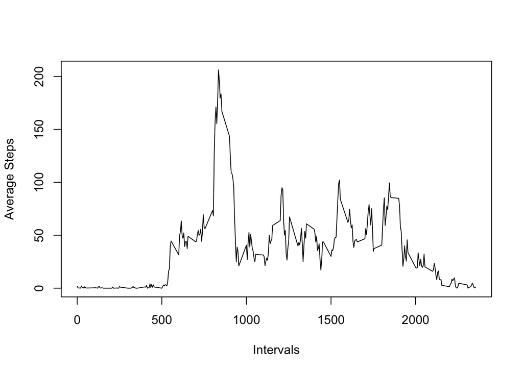

```r
qr<-na.omit(q)
avb<-aggregate(qr[,"steps"],by=list(qr[,"interval"]),mean)
plot(y=avb$x,x=avb$Group.1,type="l",ylab="Average Steps",xlab="Intervals")
```

2. The maximum number of steps across all dates is 806, and it occurs at the 615 5-minute interval:

```r
subset(qr,qr[,"steps"] == max(qr[,"steps"]))
```

```
##       steps       date interval
## 16492   806 2012-11-27      615
```

Imputing missing values

1. There are this many missing values in the dataset:

```r
length(which(is.na(q)))
```

```
## [1] 2304
```

2. Missing values will be replaced with zeroes
3. This is a new dataset with those missing values imputed with zeroes

```r
qrna<-q
qrna[is.na(qrna)]<-0
```

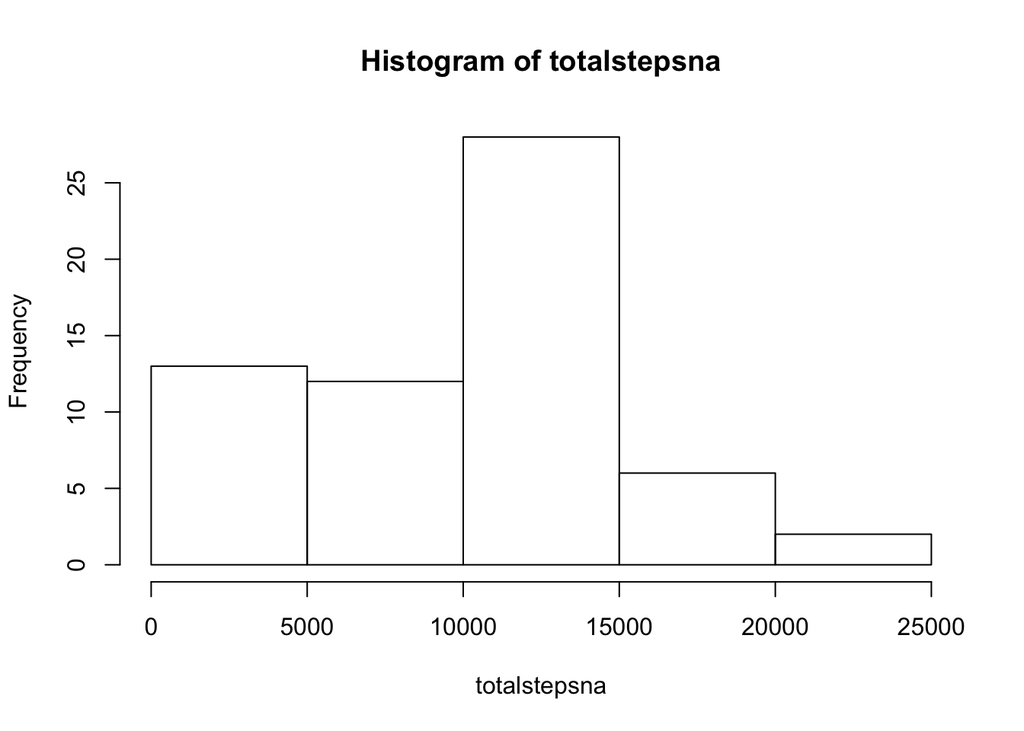

```r
sna<-aggregate(qrna$steps,by=list(qrna$date),sum)
totalstepsna<-sna$x
hist(totalstepsna)
```

```r
aggregate(qrna$steps,by=list(qrna$date),mean)
```

```
##       Group.1       x
## 1  2012-10-01  0.0000
## 2  2012-10-02  0.4375
## 3  2012-10-03 39.4167
## 4  2012-10-04 42.0694
## 5  2012-10-05 46.1597
## 6  2012-10-06 53.5417
## 7  2012-10-07 38.2465
## 8  2012-10-08  0.0000
## 9  2012-10-09 44.4826
## 10 2012-10-10 34.3750
## 11 2012-10-11 35.7778
## 12 2012-10-12 60.3542
## 13 2012-10-13 43.1458
## 14 2012-10-14 52.4236
```

[output cut: 47 more lines]

```r
aggregate(qrna$steps,by=list(qrna$date),median)
```

```
##       Group.1 x
## 1  2012-10-01 0
## 2  2012-10-02 0
## 3  2012-10-03 0
## 4  2012-10-04 0
## 5  2012-10-05 0
## 6  2012-10-06 0
## 7  2012-10-07 0
## 8  2012-10-08 0
## 9  2012-10-09 0
## 10 2012-10-10 0
## 11 2012-10-11 0
## 12 2012-10-12 0
## 13 2012-10-13 0
## 14 2012-10-14 0
```

[output cut: 47 more lines]

Are there differences in activity patterns between weekdays and weekends?

For this part the weekdays() function may be of some help here. Use the dataset with the filled-in missing values for this part.

1. Create a new factor variable in the dataset with two levels – “weekday” and “weekend” indicating whether a given date is a weekday or weekend day.

```r
qrna["weekday_flag3"] <- ifelse((qrna$weekday_flag2 == 6 | qrna$weekday_flag2 == 0),"weekend","weekday")
qrnag<-aggregate(qrna[,"steps"],by=list(qrna[,"interval"],qrna[,"weekday_flag3"]),mean)
```

[figure not shown]

```r
qrnawd<-qrnag[qrnag$Group.2=="weekday",]
plot(x=qrnawd$Group.1, y=qrnawd$x,type="l", xlab="interval",ylab="steps", xlim=c(0,2500),ylim=c(0,300))
```

[figure not shown]

```r
qrnawe<-qrnag[qrnag$Group.2=="weekend",]
plot(x=qrnawe$Group.1, y=qrnawe$x,type="l", xlab="interval",ylab="steps", xlim=c(0,2500),ylim=c(0,300))
```